# Lab 2: Comparing Word Embeddings Across Domains

In this lab, we'll explore how word2vec learns semantic relationships in different domains by comparing embeddings trained on two very different corpora:

1. Song lyrics from the Spotify Million Song Dataset
2. Biomedical paper abstracts from PubMed

An important note: The biomedical corpus was trained on substantially more data than the lyrics corpus. This means that some of the differences we observe may be due to data volume rather than domain-specific patterns. However, this itself provides an interesting angle for analysis - how does data volume affect the capture of different types of semantic relationships?

## Learning Objectives

- Understand how domain and training data affect learned word relationships
- Compare semantic patterns across different domains
- Analyze differences between input and output embeddings
- Develop systematic approaches for embedding analysis

## Setup and Data Loading

```python
import pandas as pd
import numpy as np
from gensim.models import Word2Vec
import multiprocessing
from nltk.tokenize import word_tokenize
# import nltk
# nltk.download('punkt')  # Download tokenizer data
# nltk.download('averaged_perceptron_tagger')
import seaborn as sns

from IPython.core.interactiveshell import InteractiveShell
InteractiveShell.ast_node_interactivity = "all"

from scipy.stats import spearmanr
import matplotlib.pyplot as plt
from typing import Dict, List, Tuple


pd.options.display.max_columns=None
```

```python
abstracts_model = Word2Vec.load('https://www.dropbox.com/scl/fi/fktop15arvcy4nitkakmm/word2vec_abstractso.model?rlkey=20nonez9il815khk0j9yz4cqz&st=x8rh5h2k&dl=1')
songs_model = Word2Vec.load('https://www.dropbox.com/scl/fi/t5ac16sbccqu682rdqmez/song_lyrics.model?rlkey=5ry4v06f9e3jdkhma9efc8f9r&st=8gfldsoz&dl=1')
```

```python
# Print basic model info
print("Biomedical Model:")
print(f"Vocabulary size: {len(abstracts_model.wv.key_to_index)}")
print(f"Vector size: {abstracts_model.vector_size}")

print("\nSong Lyrics Model:")
print(f"Vocabulary size: {len(songs_model.wv.key_to_index)}")
print(f"Vector size: {songs_model.vector_size}")
```

```
Biomedical Model:
Vocabulary size: 51380
Vector size: 100

Song Lyrics Model:
Vocabulary size: 12529
Vector size: 100
```

# Part 1: Word Similarity Analysis

To compare how words are represented across our two domains (biomedical papers and song lyrics), we'll conduct an analysis of their similarity patterns:

```python
def compare_similarities(word: str,
                       models: Dict[str, Word2Vec],
                       topn: int = 5) -> Dict[str, List[Tuple[str, float]]]:
    """
    Compare most similar words across different models

    Args:
        word: Target word to analyze
        models: Dictionary of domain models
        topn: Number of similar words to return

    Returns:
        Dictionary of similar words for each domain
    """
    results = {}
    for domain, model in models.items():
        if word in model.wv:
            results[domain] = model.wv.most_similar(word, topn=topn)
        else:
            results[domain] = []
    return results

def calculate_rank_correlation(word: str,
                             model1: Word2Vec,
                             model2: Word2Vec,
                             common_words: List[str]) -> float:
    """
    Calculate rank correlation of similarities between two models

    Args:
        word: Target word
        model1, model2: Models to compare
        common_words: List of words to compare similarities for

    Returns:
        Spearman rank correlation coefficient
    """
    if word not in model1.wv or word not in model2.wv:
        return None

    # Get similarities to common words in both models
    sims1 = [model1.wv.similarity(word, w) for w in common_words if w in model1.wv]
    sims2 = [model2.wv.similarity(word, w) for w in common_words if w in model2.wv]

    if len(sims1) > 1 and len(sims2) > 1:
        return spearmanr(sims1, sims2)[0]
    return None

# Create dictionary of models
models = {
    'biomedical': abstracts_model,
    'lyrics': songs_model
}
```

```python
# First get common words between models
common_words = list(set(abstracts_model.wv.key_to_index) &
                   set(songs_model.wv.key_to_index))
print(f"Number of words in both domains: {len(common_words)}")
print(f"Share of words in abstracts that are in songs: {len(common_words) / len(abstracts_model.wv.key_to_index):.3f}")
print(f"Share of words in songs that are in abstracts: {len(common_words) / len(songs_model.wv.key_to_index):.3f}")
```

```
Number of words in both domains: 6810
Share of words in abstracts that are in songs: 0.133
Share of words in songs that are in abstracts: 0.544
```

```python
sample_of_common_words = pd.DataFrame(common_words, columns=['word']).sample(1000)
```

```python
center = {}
for i, cw in enumerate(sample_of_common_words.values):
    if i % 250 == 0:
        print(i, sample_of_common_words.shape[0])
    sim_words = compare_similarities(cw[0], models, 7000)
    df_bio = pd.DataFrame(sim_words['biomedical'], columns=['word', 'sim'])
    df_song = pd.DataFrame(sim_words['lyrics'], columns=['word', 'sim'])
    df = df_bio.merge(df_song, on=['word'], suffixes=['_bio', '_song'])
    center[cw[0]] = df.iloc[:, 1:].corr(method='spearman').iloc[0, 1]
```

```
0 1000
250 1000
500 1000
750 1000
```

```python
rank_corrs = pd.DataFrame.from_dict(center, orient='index').reset_index()
rank_corrs.columns=['word', 'corr']
rank_corrs.sort_values(by='corr', inplace=True)
```

```python
# 20 least correlated
rank_corrs.head(20)
```

|  | word | corr |
| --- | --- | --- |
| 939 | ova | -0.137636 |
| 799 | steer | -0.136511 |
| 474 | blocking | -0.096959 |
| 361 | gene | -0.094439 |
| 614 | collector | -0.088616 |
| 747 | dr | -0.084789 |
| 601 | hut | -0.077672 |
| 845 | mccoy | -0.075706 |
| 626 | horn | -0.075189 |
| 291 | sanctuary | -0.073536 |
| 941 | volume | -0.068567 |
| 243 | prime | -0.064830 |
| 731 | sera | -0.061896 |
| 776 | breeds | -0.061139 |
| 164 | web | -0.059445 |
| 606 | timothy | -0.058925 |
| 599 | bid | -0.058215 |
| 736 | solutions | -0.056910 |
| 655 | admission | -0.055799 |
| 492 | grit | -0.052010 |

```python
# 20 most correlated
rank_corrs.tail(20)
```

|  | word | corr |
| --- | --- | --- |
| 110 | eastern | 0.350956 |
| 480 | florida | 0.355719 |
| 623 | salad | 0.356657 |
| 42 | birmingham | 0.359916 |
| 324 | cherry | 0.363270 |
| 47 | usa | 0.363541 |
| 56 | france | 0.374994 |
| 734 | baking | 0.378058 |
| 877 | des | 0.379742 |
| 330 | wine | 0.380003 |
| 968 | suburbs | 0.380126 |
| 846 | italy | 0.380626 |
| 318 | nevada | 0.388096 |
| 300 | avec | 0.389604 |
| 97 | atlanta | 0.396447 |
| 262 | spain | 0.403125 |
| 299 | detroit | 0.406309 |
| 334 | york | 0.415983 |
| 716 | fruit | 0.417101 |
| 36 | missouri | 0.448314 |

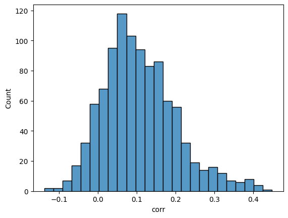

```python
# The distrubtion of rank correlations
sns.histplot(rank_corrs, x='corr')
```

### Excercises:

Consider the following hypothesis: Geographic terms show high cross-domain correlation because they participate in similar semantic relationships across domains, even when the specific contexts of their usage differ. This is because geographic relationships (like country-capital pairs, regional groupings, or spatial relationships) are fundamental and consistent, unlike more context-dependent relationships like those between emotions or technical terms.

1. Take some of the geography related words that had high correlations and look at which words are closest to them in the two domains (biomedical and song lyrics). Is the relationship between the source word and the neighbors words similar in the two domains?

```python
for word in ['japan', 'alabama', 'eastern', 'massachusetts']:
    print(word)
    pd.DataFrame({
        'top_10_abstract' :abstracts_model.wv.most_similar(word, topn=10),
        'top_10_songs' :   songs_model.wv.most_similar(word, topn=10)})
    print('=' * 20)
```

```
japan
```

|  | top_10_abstract | top_10_songs |
| --- | --- | --- |
| 0 | (korea, 0.8748170733451843) | (miami, 0.5309703350067139) |
| 1 | (israel, 0.8398821949958801) | (seattle, 0.5086838006973267) |
| 2 | (italy, 0.8218989372253418) | (bombay, 0.501028299331665) |
| 3 | (france, 0.8159109354019165) | (milwaukee, 0.49392423033714294) |
| 4 | (germany, 0.8139998912811279) | (canada, 0.4893510937690735) |
| 5 | (taiwan, 0.8009180426597595) | (eastern, 0.4831640422344208) |
| 6 | (poland, 0.7939981818199158) | (peru, 0.48271527886390686) |
| 7 | (austria, 0.7908223867416382) | (italy, 0.47260430455207825) |
| 8 | (canada, 0.7870953679084778) | (texas, 0.4703732132911682) |
| 9 | (australia, 0.7857426404953003) | (tennessee, 0.46824613213539124) |

```
====================
alabama
```

|  | top_10_abstract | top_10_songs |
| --- | --- | --- |
| 0 | (ohio, 0.8161562085151672) | (alabam, 0.5872521996498108) |
| 1 | (carolina, 0.8154383301734924) | (birmingham, 0.5807199478149414) |
| 2 | (texas, 0.8063473701477051) | (kentucky, 0.5631315112113953) |
| 3 | (washington, 0.797336757183075) | (georgia, 0.5521689057350159) |
| 4 | (bronx, 0.7942252159118652) | (louisiana, 0.54639732837677) |
| 5 | (michigan, 0.7938581109046936) | (headin, 0.5460915565490723) |
| 6 | (utah, 0.7937974333763123) | (south, 0.5328818559646606) |
| 7 | (california, 0.7934910655021667) | (florida, 0.5296846628189087) |
| 8 | (maryland, 0.7933011054992676) | (kansas, 0.5220784544944763) |
| 9 | (houston, 0.7924526929855347) | (missouri, 0.5115543603897095) |

```
====================
eastern
```

|  | top_10_abstract | top_10_songs |
| --- | --- | --- |
| 0 | (southern, 0.840345561504364) | (north, 0.5851677656173706) |
| 1 | (north, 0.8231372833251953) | (east, 0.5750294923782349) |
| 2 | (west, 0.8209653496742249) | (african, 0.5740207433700562) |
| 3 | (southeast, 0.811873733997345) | (across, 0.5662868022918701) |
| 4 | (northern, 0.7906352877616882) | (redwood, 0.5559266209602356) |
| 5 | (northeast, 0.7843962907791138) | (ridge, 0.5410141944885254) |
| 6 | (east, 0.7805769443511963) | (south, 0.5373070240020752) |
| 7 | (southwest, 0.7763235569000244) | (mountain, 0.5371017456054688) |
| 8 | (south, 0.7742679715156555) | (oceans, 0.5346466898918152) |
| 9 | (southwestern, 0.7726342678070068) | (sea, 0.5311489105224609) |

```
====================
massachusetts
```

|  | top_10_abstract | top_10_songs |
| --- | --- | --- |
| 0 | (ohio, 0.8244689702987671) | (south, 0.5175922513008118) |
| 1 | (missouri, 0.8058115839958191) | (ohio, 0.5163834095001221) |
| 2 | (pennsylvania, 0.8054637908935547) | (nashville, 0.5137845277786255) |
| 3 | (connecticut, 0.8047425746917725) | (indiana, 0.4909800887107849) |
| 4 | (texas, 0.8038879036903381) | (memphis, 0.48726528882980347) |
| 5 | (virginia, 0.8029403686523438) | (mexico, 0.4843578636646271) |
| 6 | (california, 0.7953702807426453) | (san, 0.481657475233078) |
| 7 | (washington, 0.7941966652870178) | (louisiana, 0.4794386923313141) |
| 8 | (carolina, 0.7905446887016296) | (tennessee, 0.47696375846862793) |
| 9 | (england, 0.789548397064209) | (kentucky, 0.46984240412712097) |

I asked Claude 3.7 to analyze these lists and its response was impressive enough that I'm pasting it below (with slight edits to remove repition). My comments are in red.

### Analysis of Cross-Domain Semantic Relationships

1. Japan

In the biomedical abstracts, 'japan' is strongly associated with:

- Other countries and regions, particularly in East Asia (korea, taiwan)
- Developed nations more broadly (israel, italy, france, germany, austria)

In song lyrics, 'japan' relates to:

- Various cities and regions across North America (miami, seattle, milwaukee)
- Other countries and regions, but with weaker similarity scores (canada, peru, italy)
- U.S. states (texas, tennessee)

The relationship pattern is fundamentally different. In biomedical literature, Japan clusters with other countries in an expected geopolitical/taxonomic organization. In lyrics, Japan appears to function more as an exotic or distant reference point alongside various cities and places that might evoke similar emotional or cultural connotations in songs.

Claude doesn't know the difference in dataset size here, so some of the lack of specificity in the song lyric dataset may be driven by that as well.

2. Alabama

In biomedical abstracts, 'alabama' clusters with:

- Other U.S. states (ohio, texas, michigan, utah, california)
- State-like entities (carolina, washington)
- Cities (bronx, houston)

In song lyrics, 'alabama' relates to:

- Its own dialectal variant (alabam)
- Nearby southern states (kentucky, georgia, louisiana)
- Directional terms (south, headin')

Here we see stronger consistency - Alabama functions as a U.S. state in both domains, but in lyrics there's a stronger regional identity element (clustering with other southern states) and contextual usage (related to travel - 'headin'). In biomedical literature, the relationship appears more strictly taxonomic.

Given how Japan is so clearly identified with other countires, I'm not sure what explains the presence of Bronx or Houston here.

3. Eastern

For the directional term 'eastern', we see: In biomedical abstracts:

- Other cardinal and ordinal directions (southern, north, west, southeast)
- Compound directional terms (northeast, southwest)

In song lyrics:

- Cardinal directions (north, east, south)
- Natural geographic features (redwood, ridge, mountain, oceans, sea)
- A cultural reference (african)

This term shows the most consistency between domains - directional relationships remain similar, though song lyrics incorporate more physical geography and cultural associations.

Interpretation

- Functional vs. Referential Usage: Geographic terms maintain their basic referential meaning across domains (Japan is still a country, Alabama is still a state), but their functional role varies. In biomedical literature, geographic terms tend to operate in taxonomic, classificatory relationships, while in lyrics they often serve emotional, cultural, or metaphorical purposes.
- Strength of Association: Notice the significant difference in similarity scores. Biomedical abstracts show much stronger associations (most 0.7-0.8 range) compared to lyrics (mostly 0.4-0.5 range). This suggests geographic relationships are more consistently structured in academic writing than in creative contexts.

This may again be driven by difference in dataset size

- Regional Identity: Terms like 'alabama' reveal cultural clusters in lyrics (Southern states) that differ from the more generalized state-state relationships in academic text.
- Methodological Implications: These findings suggest that while geographic terms do transfer between domains better than many other semantic categories, the nature of their relationships differs. The relatively high cross-domain correlation likely comes from the stable referential core meaning rather than from identical contextual usage patterns.

This analysis provides qualified support for the hypothesis. Geographic terms do show consistency in their basic referential meaning across domains, but the specific semantic relationships they participate in remain domain-dependent. The fundamental geographic relationships (what is a country, what is a state) transfer well, but the contextual associations and functional uses of these terms vary considerably between scientific and creative writing.

Going back to the original hypothesis: "Geographic terms show high cross-domain correlation because they participate in similar semantic relationships across domains, even when the specific contexts of their usage differ." I'd say Claude 3.7 is being somewhat generous to the hypothesis --- the collocation patterns across the two datasets show that while there are semantic relationships that exist in both datasets (Japan as country, Alabama as state, eastern as direction), there are also certain semantic relationships that are present in one dataset but not the other (in particular, the use of geographical terms for emotive effect).

2. Take some emotion-related or technicial/scientific-related terms and investigate the nearest words across the two domains. Do these neighboring words support the hypothesis above? What is the difference in the contexts that appear in the two lists?

```python
# emotion words are less common in the abstracts
for word in ['results', 'loss',  'gene',  'relationship', 'alcohol']:
    print(word)
    pd.DataFrame({
        'top_10_abstract' :abstracts_model.wv.most_similar(word, topn=10),
        'top_10_songs' :   songs_model.wv.most_similar(word, topn=10)})
    print('=' * 20)
```

```
results
```

|  | top_10_abstract | top_10_songs |
| --- | --- | --- |
| 0 | (findings, 0.7533902525901794) | (conspiracy, 0.5340604186058044) |
| 1 | (data, 0.7228420376777649) | (environment, 0.5331812500953674) |
| 2 | (observations, 0.6540159583091736) | (progress, 0.5310154557228088) |
| 3 | (analyses, 0.6239864826202393) | (result, 0.5276044011116028) |
| 4 | (altogether, 0.621438205242157) | (delusion, 0.5232785940170288) |
| 5 | (conclusions, 0.6182958483695984) | (decisions, 0.5207023024559021) |
| 6 | (these, 0.5967600345611572) | (education, 0.5119056701660156) |
| 7 | (and, 0.5799633264541626) | (value, 0.5096239447593689) |
| 8 | (analysis, 0.5782771110534668) | (appearance, 0.5045484900474548) |
| 9 | (conclusion, 0.5779496431350708) | (failure, 0.5006080865859985) |

```
====================
loss
```

|  | top_10_abstract | top_10_songs |
| --- | --- | --- |
| 0 | (gain, 0.655653715133667) | (control, 0.6872790455818176) |
| 1 | (losses, 0.6424258947372437) | (gain, 0.5800700187683105) |
| 2 | (regain, 0.635229229927063) | (self, 0.5547401905059814) |
| 3 | (weight, 0.5950466394424438) | (losing, 0.5478525757789612) |
| 4 | (reduction, 0.583220899105072) | (destruction, 0.5409050583839417) |
| 5 | (sensorineural, 0.5607789754867554) | (suffering, 0.5388063192367554) |
| 6 | (lost, 0.5604578256607056) | (grief, 0.5065642595291138) |
| 7 | (gains, 0.5603702664375305) | (simplicity, 0.4994810223579407) |
| 8 | (arhl, 0.5533477663993835) | (civilized, 0.49618569016456604) |
| 9 | (lose, 0.5489565134048462) | (sanity, 0.49227234721183777) |

```
====================
gene
```

|  | top_10_abstract | top_10_songs |
| --- | --- | --- |
| 0 | (genes, 0.8073875308036804) | (dean, 0.4854452610015869) |
| 1 | (transcript, 0.7708730697631836) | (hangover, 0.46422114968299866) |
| 2 | (promoter, 0.7615336179733276) | (fat, 0.4489145874977112) |
| 3 | (expression, 0.7515049576759338) | (cluck, 0.4478444457054138) |
| 4 | (reln, 0.7510012984275818) | (teddy, 0.44257891178131104) |
| 5 | (transcriptional, 0.7473430633544922) | (tub, 0.43551725149154663) |
| 6 | (chrna7, 0.7427319884300232) | (redneck, 0.4352358877658844) |
| 7 | (wnt2, 0.7347682118415833) | (vinnie, 0.43189749121665955) |
| 8 | (akap12, 0.7296922206878662) | (pool, 0.43134692311286926) |
| 9 | (cdkn1c, 0.7295920848846436) | (mascara, 0.4261293411254883) |

```
====================
relationship
```

|  | top_10_abstract | top_10_songs |
| --- | --- | --- |
| 0 | (relationships, 0.8824570775032043) | (problem, 0.5246297717094421) |
| 1 | (relation, 0.8729956746101379) | (situation, 0.5208447575569153) |
| 2 | (association, 0.8719602823257446) | (mutual, 0.4890507161617279) |
| 3 | (associations, 0.8337894678115845) | (opinion, 0.48446422815322876) |
| 4 | (relations, 0.824416995048523) | (situations, 0.4682455062866211) |
| 5 | (link, 0.7976319193840027) | (this, 0.46032848954200745) |
| 6 | (links, 0.7719379663467407) | (serious, 0.45658427476882935) |
| 7 | (interrelationship, 0.7520392537117004) | (type, 0.4560496509075165) |
| 8 | (interrelation, 0.7385400533676147) | (intention, 0.44663071632385254) |
| 9 | (interrelationships, 0.7377327680587769) | (problems, 0.4459305703639984) |

```
====================
alcohol
```

|  | top_10_abstract | top_10_songs |
| --- | --- | --- |
| 0 | (marijuana, 0.8451120853424072) | (gimmie, 0.6309528946876526) |
| 1 | (drinking, 0.8213468194007874) | (vodka, 0.5660660266876221) |
| 2 | (cannabis, 0.8138123154640198) | (pills, 0.5207496285438538) |
| 3 | (methamphetamine, 0.8100548386573792) | (gin, 0.4987192153930664) |
| 4 | (binge, 0.8048396110534668) | (champagne, 0.4806707203388214) |
| 5 | (dependence, 0.7954674959182739) | (drinking, 0.46205461025238037) |
| 6 | (cocaine, 0.7905853390693665) | (demon, 0.4595335125923157) |
| 7 | (heroin, 0.7748849391937256) | (bottle, 0.45356303453445435) |
| 8 | (substance, 0.7657745480537415) | (whiskey, 0.44766926765441895) |
| 9 | (nicotine, 0.7656602263450623) | (fax, 0.44533926248550415) |

Unlike geographic terms, we see that these emotion/technical terms (that have some overlap across the two datasets), participate in very different semantic relationships across the two datasets. Most interestingly to me is the role of alcohol in biomedical abstracts vs song lyrics. In the former, alcohol clusters with other substances that can be abused, whereas in the latter, alcohol clusters with more specific kinds of alcohol.

# Part 2: Understanding Input and Output Vector Spaces

Now we'll dive deeper into an interesting aspect of the word2vec architecture: the distinction between input and output vectors.

When word2vec trains, it actually learns two different vector representations for each word:

- The first representation is the input vector, which we get from what's called the input embedding matrix. When we feed a target word like "pizza" into the model, we use its input vector to try to predict the surrounding context words. Think of this input vector as capturing how useful a word is for predicting what words might appear around it. It represents the word's role as a clue or predictor.
- The second representation is the output vector, stored in what's called the output embedding matrix. These vectors represent words in their role as predictions or answers. When our model sees "pizza" and tries to predict "delicious," it compares the input vector for "pizza" with the output vector for "delicious." The more closely these vectors align, the more confident the model is in predicting that relationship.
- These two representations emerge from the model's training objective. When we say "dog" appears in the context of "bark", the model uses the input vector for "dog" to help predict "bark". But when "dog" is the word being predicted, the model uses its output vector. In theory, these vectors could capture different aspects of meaning - the input vector might represent how a word helps predict other words, while the output vector represents how that word is predicted by its context.

This raises some interesting questions:

- How similar are a word's input and output vectors?
- Do some types of words have more consistent representations across these spaces than others?
- Does this consistency relate to properties like:
- Word frequency (do common words have more consistent representations?)
- Part of speech (do nouns behave differently than verbs?)
- Word length (do longer, potentially more complex words show different patterns?)
- Do these patterns differ between our biomedical and lyrics domains?

Understanding these patterns can give us insight into how word2vec learns to represent meaning and whether words play different roles when providing context versus being predicted. Let's start exploring this by calculating the cosine similarity between each word's input and output vectors.

```
Analyzing input-output similarities...
```

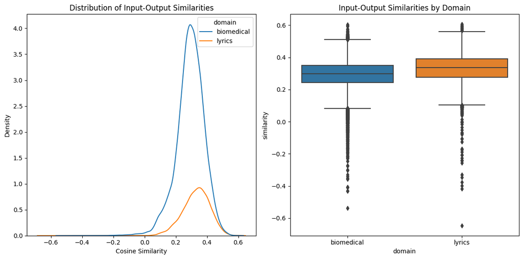

```python
def analyze_input_output_similarity(model: Word2Vec):
    """
    Analyze the cosine similarity between input and output vectors for each word.

    This function examines how similarly words are represented in the input space
    (when they serve as context) versus the output space (when they are being predicted).
    A high similarity suggests the word has consistent representation across both spaces.

    Returns:
        DataFrame containing word-level similarity scores and vector statistics
    """
    similarities = []

    for word in model.wv.index_to_key:
        # Get input and output vectors
        input_vec = model.wv[word]
        output_vec = model.syn1neg[model.wv.key_to_index[word]]

        # Normalize vectors
        input_norm = np.linalg.norm(input_vec)
        output_norm = np.linalg.norm(output_vec)
        input_vec_norm = input_vec / input_norm
        output_vec_norm = output_vec / output_norm

        # Calculate cosine similarity
        similarity = np.dot(input_vec_norm, output_vec_norm)

        similarities.append({
            'word': word,
            'similarity': similarity,
            'input_norm': input_norm,
            'output_norm': output_norm
        })

    return pd.DataFrame(similarities)

# Analyze both models
print("Analyzing input-output similarities...")
bio_similarities = analyze_input_output_similarity(abstracts_model)
lyrics_similarities = analyze_input_output_similarity(songs_model)

# Add domain labels
bio_similarities['domain'] = 'biomedical'
lyrics_similarities['domain'] = 'lyrics'

# Combine results
all_similarities = pd.concat([bio_similarities, lyrics_similarities])

# Create visualizations to compare distributions
plt.figure(figsize=(12, 6))

# Distribution plot
plt.subplot(1, 2, 1)
sns.kdeplot(data=all_similarities, x='similarity', hue='domain')
plt.title('Distribution of Input-Output Similarities')
plt.xlabel('Cosine Similarity')

# Box plot
plt.subplot(1, 2, 2)
sns.boxplot(data=all_similarities, x='domain', y='similarity')
plt.title('Input-Output Similarities by Domain')

plt.tight_layout()
```

```python
# Function to analyze extreme cases
def analyze_extreme_cases(df: pd.DataFrame, n: int = 10) -> dict:
    """
    Analyze words with highest and lowest input-output similarities.

    This helps us understand which words have consistent representations
    across spaces versus those that are represented differently.
    """
    results = {}

    # Get extreme cases for each domain
    for domain in df['domain'].unique():
        domain_df = df[df['domain'] == domain]

        most_similar = domain_df.nlargest(n, 'similarity')[['word', 'similarity']]
        least_similar = domain_df.nsmallest(n, 'similarity')[['word', 'similarity']]

        results[domain] = {
            'most_similar': most_similar,
            'least_similar': least_similar
        }

    return results

# Analyze extreme cases
extreme_cases = analyze_extreme_cases(all_similarities)

# Print findings
for domain, cases in extreme_cases.items():
    print(f"\n{domain.upper()} DOMAIN")
    print("=" * 50)

    print("\nMost similar input-output representations:")
    print(cases['most_similar'].to_string(index=False))

    print("\nLeast similar input-output representations:")
    print(cases['least_similar'].to_string(index=False))
```

```
BIOMEDICAL DOMAIN
==================================================

Most similar input-output representations:
         word  similarity
    composite    0.603318
        white    0.599204
       middle    0.593259
 longitudinal    0.576476
       living    0.572975
        heavy    0.565382
        fiber    0.563679
       bundle    0.563099
consolidation    0.561041
   attachment    0.558926

Least similar input-output representations:
        word  similarity
         and   -0.536199
          of   -0.430385
         the   -0.430200
     besides   -0.410197
          in   -0.407083
      whilst   -0.358159
    addition   -0.351917
additionally   -0.340453
         was   -0.329975
        with   -0.303203

LYRICS DOMAIN
==================================================

Most similar input-output representations:
   word  similarity
   bang    0.606021
  fever    0.598021
     oo    0.595833
   funk    0.592830
   boom    0.588909
     la    0.583475
    bop    0.582034
america    0.575650
   rock    0.572892
    bow    0.569074

Least similar input-output representations:
word  similarity
 and   -0.645927
 you   -0.415907
that   -0.398828
 the   -0.374967
 but   -0.345375
  to   -0.329941
  my   -0.255253
  in   -0.242977
your   -0.241031
  me   -0.225409
```

```python
# Calculate summary statistics
summary_stats = all_similarities.groupby('domain').agg({
    'similarity': ['mean', 'std', 'median', 'min', 'max']
}).round(3)

print("\nSummary Statistics:")
print(summary_stats)
```

```
Summary Statistics:
           similarity
                 mean    std median    min    max
domain
biomedical      0.292  0.089  0.297 -0.536  0.603
lyrics          0.330  0.089  0.337 -0.646  0.606
```

#### Excercises

1. Write a function that returns the top n most similar words in the output embeddings space. (The `wv.most_similar` function that comes with gensim is for the input embeddings here.).

```python
def most_similar_output(model, word, topn=10):
    """
    Find the most similar words to a given word in the output embedding space.

    Parameters:
        model: The Word2Vec model
        word: The target word to find similarities for
        topn: Number of top similar words to return

    Returns:
        List of (word, similarity) tuples
    """
    # Get the output vector for the target word
    if word not in model.wv.key_to_index:
        return []

    target_index = model.wv.key_to_index[word]
    target_output_vec = model.syn1neg[target_index]

    # Normalize the target vector
    target_norm = np.linalg.norm(target_output_vec)
    if target_norm == 0:
        return []
    target_output_vec_norm = target_output_vec / target_norm

    # Calculate similarities with all other output vectors
    similarities = []
    for i, other_word in enumerate(model.wv.index_to_key):
        if other_word == word:  # Skip the target word itself
            continue

        other_output_vec = model.syn1neg[i]
        other_norm = np.linalg.norm(other_output_vec)

        if other_norm == 0:
            continue

        other_output_vec_norm = other_output_vec / other_norm
        similarity = np.dot(target_output_vec_norm, other_output_vec_norm)
        similarities.append((other_word, similarity))

    # Sort by similarity (highest first) and return top n
    return sorted(similarities, key=lambda x: x[1], reverse=True)[:topn]
```

```python
# Example use
most_similar_output(abstracts_model, 'chain')
most_similar_output(songs_model, 'chain')
```

```
[('polymerase', 0.9043478),
 ('reaction', 0.80934185),
 ('rtpcr', 0.7943145),
 ('pcr', 0.7834429),
 ('qpcr', 0.7749369),
 ('reverse', 0.7698043),
 ('rflp', 0.768584),
 ('fragment', 0.7580474),
 ('multiplex', 0.74632204),
 ('sybr', 0.74082845)]
```

```
[('ball', 0.723468),
 ('chains', 0.71177894),
 ('links', 0.7097362),
 ('rollie', 0.69211906),
 ('whips', 0.686039),
 ('presidential', 0.6775297),
 ('whip', 0.673292),
 ('link', 0.6658155),
 ('binds', 0.66426957),
 ('wrecking', 0.6631808)]
```

2. Using the function that you wrote, look at the most similar words for the most similar and least similar words (when comparing input- and output-embeddings). Do this for both domains.

Do words with high input/output similarity also have the same closest words? What about for words with low input/output similarity?

```python
# First, let's get some example words from each domain
def analyze_input_vs_output_similarities(model, domain_name, top_words, bottom_words):
    print(f"\n{domain_name.upper()} DOMAIN ANALYSIS")
    print("=" * 60)

    print("\nWords with HIGH input-output similarity:")
    for word, sim in top_words:
        print(f"\nWord: '{word}' (input-output similarity: {sim:.4f})")

        print("Top 5 similar words in INPUT space:")
        input_similar = model.wv.most_similar(word, topn=10)
        for w, s in input_similar:
            print(f"  {w:<15} {s:.4f}")

        print("Top 5 similar words in OUTPUT space:")
        output_similar = most_similar_output(model, word, topn=10)
        for w, s in output_similar:
            print(f"  {w:<15} {s:.4f}")

    print("\nWords with LOW input-output similarity:")
    for word, sim in bottom_words:
        print(f"\nWord: '{word}' (input-output similarity: {sim:.4f})")

        print("Top 5 similar words in INPUT space:")
        input_similar = model.wv.most_similar(word, topn=10)
        for w, s in input_similar:
            print(f"  {w:<15} {s:.4f}")

        print("Top 5 similar words in OUTPUT space:")
        output_similar = most_similar_output(model, word, topn=10)
        for w, s in output_similar:
            print(f"  {w:<15} {s:.4f}")

# For biomedical domain
bio_top = extreme_cases['biomedical']['most_similar'].head(3).values.tolist()
bio_bottom = extreme_cases['biomedical']['least_similar'].head(3).values.tolist()
analyze_input_vs_output_similarities(abstracts_model, "Biomedical", bio_top, bio_bottom)
```

```
BIOMEDICAL DOMAIN ANALYSIS
============================================================

Words with HIGH input-output similarity:

Word: 'composite' (input-output similarity: 0.6033)
Top 5 similar words in INPUT space:
  nanohybrid      0.6597
  composites      0.6585
  cgic            0.6435
  nanofilled      0.6429
  microhybrid     0.6401
  flowable        0.6352
  z250            0.6344
  compomer        0.6234
  silorane        0.6190
  rmgi            0.6144
Top 5 similar words in OUTPUT space:
  composites      0.7235
  cgic            0.7175
  flowable        0.6886
  rmgi            0.6787
  nanohybrid      0.6742
  compomer        0.6737
  cpc             0.6704
  microhybrid     0.6684
  endpoint        0.6544
  nanofilled      0.6533

Word: 'white' (input-output similarity: 0.5992)
Top 5 similar words in INPUT space:
  black           0.7710
  hispanic        0.6778
  hyperintensities 0.6636
  latinx          0.6400
  multiracial     0.6331
  matter          0.6318
  african         0.6196
  islander        0.6152
  juxtacortical   0.6095
```

[output cut: 95 more lines]

```
  which           0.5954
  each            0.5904
  in              0.5894
  their           0.5759
Top 5 similar words in OUTPUT space:
  of              0.7850
  backgroundthe   0.7333
  summarythe      0.7294
  besides         0.7210
  secondly        0.7154
  and             0.7110
  pdp             0.7102
  2020            0.7060
  isp             0.6998
  accordingly     0.6990
```

```python
# For lyrics domain
lyrics_top = extreme_cases['lyrics']['most_similar'].head(3).values.tolist()
lyrics_bottom = extreme_cases['lyrics']['least_similar'].head(3).values.tolist()
analyze_input_vs_output_similarities(songs_model, "Lyrics", lyrics_top, lyrics_bottom)
```

```
LYRICS DOMAIN ANALYSIS
============================================================

Words with HIGH input-output similarity:

Word: 'bang' (input-output similarity: 0.6060)
Top 5 similar words in INPUT space:
  shoot           0.5559
  shot            0.5504
  diggy           0.5197
  gong            0.5138
  lulu            0.4982
  headboard       0.4626
  buh             0.4447
  bangin          0.4421
  click           0.4366
  boomerang       0.4365
Top 5 similar words in OUTPUT space:
  bangin          0.6654
  chicka          0.6542
  gong            0.6520
  shoot           0.6468
  ano             0.6417
  diggy           0.6385
  shot            0.6325
  headboard       0.6298
  buh             0.6251
  mj              0.6214

Word: 'fever' (input-output similarity: 0.5980)
Top 5 similar words in INPUT space:
  jungle          0.5648
  hot             0.5173
  sizzle          0.4628
  homesick        0.4439
  bloodbath       0.4374
  temperature     0.4370
  itching         0.4230
  summer          0.4230
  fan             0.4183
```

[output cut: 95 more lines]

```
  sure            0.6014
  really          0.5998
  know            0.5969
  if              0.5813
Top 5 similar words in OUTPUT space:
  you             0.8712
  but             0.8647
  and             0.8424
  sensible        0.8280
  yasss           0.8201
  bish            0.8198
  irrelevant      0.8143
  ironic          0.8126
  the             0.8062
  khay            0.8024
```

From Claude 3.7:

Across both domains, we see a clear pattern where content words with specific semantic meanings (like "composite" or "bang") have high input-output similarity, while function words with primarily grammatical roles (like "and" or "the") have low or negative similarity. This suggests a fundamental linguistic distinction:

- Content words maintain consistent semantic roles regardless of context
- Function words adapt their relationships dramatically based on their role in prediction

## Part 3: Testing Analogies Across Domains

Let's explore how well each model captures semantic relationships through analogy testing.

The classic example of word embeddings capturing analogies is "king:queen::man:woman" - the idea that the vector difference between "king" and "queen" is similar to the vector difference between "man" and "woman". This suggests the model has learned the concept of gender relationships and it is represented linearly.

In this section, we'll test different types of analogies in each domain. We're particularly interested in:

1. Whether certain types of relationships are better captured in one domain vs the other
2. If there are differences between how input embeddings (word vectors) and output embeddings (context vectors) capture these relationships

```python
from dataclasses import dataclass
from typing import List, Tuple, Optional, Literal

@dataclass
class Analogy:
    input_1: str
    input_2: str
    input_3: str
    expected: str
    explanation: str = ""

# Gender/Sex Relationships
gender_analogies = [
    Analogy("man", "woman", "king", "queen"),
    Analogy("father", "mother", "son", "daughter"),
    Analogy("brother", "sister", "uncle", "aunt"),
    Analogy("husband", "wife", "groom", "bride"),
    Analogy("actor", "actress", "waiter", "waitress"),
    Analogy("sir", "madam", "mr", "mrs")
]

# Geographic Relationships
geographic_analogies = [
    Analogy("france", "paris", "japan", "tokyo"),
    Analogy("russia", "moscow", "uk", "london"),
    Analogy("egypt", "cairo", "iran", "tehran"),
    Analogy("berlin", "germany", "dublin", "ireland"),
    Analogy("europe", "european", "asia", "asian")
]

# Currency Relationships
currency_analogies = [
    Analogy("japan", "yen", "uk", "pound"),
    Analogy("usa", "dollar", "europe", "euro"),
    Analogy("russia", "ruble", "china", "yuan"),
    Analogy("switzerland", "franc", "india", "rupee")
]

# Comparative/Superlative Relationships
comparative_analogies = [
    Analogy("good", "better", "bad", "worse"),
    Analogy("big", "biggest", "small", "smallest"),
    Analogy("hot", "hottest", "cold", "coldest"),
    Analogy("happy", "happiest", "sad", "saddest")
]

# Opposite Relationships
opposite_analogies = [
    Analogy("hot", "cold", "light", "dark"),
    Analogy("up", "down", "left", "right"),
    Analogy("rich", "poor", "strong", "weak"),
    Analogy("love", "hate", "friend", "enemy")
]

# Professional Relationships
professional_analogies = [
    Analogy("doctor", "hospital", "teacher", "school"),
    Analogy("chef", "restaurant", "pilot", "airplane"),
    Analogy("artist", "paint", "writer", "pen")
]
```

```python
def test_analogy_with_embeddings(model, analogy: Analogy,
                                embedding_type: Literal["input", "output", "both"] = "both",
                                topn: int = 5) -> dict:
    """
    Test analogy using specified embedding type(s) and return results in a format
    suitable for DataFrame construction.

    Returns dictionary containing:
    - Basic analogy information
    - Top n predictions for each embedding type
    - Whether expected word was found
    - Rank of expected word if found
    - Similarity score of expected word if found
    """
    results = {
        'input_1': analogy.input_1,
        'input_2': analogy.input_2,
        'input_3': analogy.input_3,
        'expected': analogy.expected
    }

    try:
        # Test input embeddings
        if embedding_type in ["input", "both"]:
            input_vec = (model.wv[analogy.input_2] -
                        model.wv[analogy.input_1] +
                        model.wv[analogy.input_3])

            input_results = model.wv.similar_by_vector(input_vec, topn=topn + 3)

            # Filter out input words
            input_results = [(word, score) for word, score in input_results
                           if word not in [analogy.input_1, analogy.input_2, analogy.input_3]][:topn]

            # Store top predictions
            results.update({'input_preds' : ', '.join(w for w, s in input_results)})

            # Check if expected word is in results
            expected_in_input = next(((i+1, score) for i, (word, score) in enumerate(input_results)
                                    if word == analogy.expected), (None, None))
            results['input_expected_rank'] = expected_in_input[0]

        # Test output embeddings
        if embedding_type in ["output", "both"]:
            output_vec = (model.syn1neg[model.wv.key_to_index[analogy.input_2]] -
                         model.syn1neg[model.wv.key_to_index[analogy.input_1]] +
                         model.syn1neg[model.wv.key_to_index[analogy.input_3]])

            output_vec = output_vec / np.linalg.norm(output_vec)

            similarities = []
            for word in model.wv.index_to_key:
                if word not in [analogy.input_1, analogy.input_2, analogy.input_3]:
                    vec = model.syn1neg[model.wv.key_to_index[word]]
                    vec = vec / np.linalg.norm(vec)
                    sim = np.dot(output_vec, vec)
                    similarities.append((word, sim))

            output_results = sorted(similarities, key=lambda x: x[1], reverse=True)[:topn]

            # Store top predictions
            results.update({'output_preds' : ', '.join(w for w,s in output_results)})

            # Check if expected word is in results
            expected_in_output = next(((i+1, score) for i, (word, score) in enumerate(output_results)
                                     if word == analogy.expected), (None, None))
            results['output_expected_rank'] = expected_in_output[0]

    except KeyError as e:
        results['error'] = str(e)

    return results

def analyze_analogies(model, analogy_sets: Dict[str, List[Analogy]], domain: str):
    """
    Test multiple sets of analogies and return results as a DataFrame
    """
    all_results = []

    for category, analogies in analogy_sets.items():
        for analogy in analogies:
            result = test_analogy_with_embeddings(model, analogy)
            result['category'] = category
            result['domain'] = domain
            all_results.append(result)

    # Create DataFrame
    df = pd.DataFrame(all_results)

    # Add success indicators
    df['input_success'] = df['input_expected_rank'].notna()
    df['output_success'] = df['output_expected_rank'].notna()
    df.drop(columns=['output_expected_rank', 'input_expected_rank'], inplace=True)

    df = df[df.input_preds.notna()]

    return df
```

```python
# Test analogies and analyze results
analogy_sets = {
    'gender': gender_analogies,
    'geographic': geographic_analogies,
    'comparative': comparative_analogies,
    'opposite': opposite_analogies,
    'professional': professional_analogies
}

# Test in both domains
results_bio = analyze_analogies(abstracts_model, analogy_sets, 'biomedical')
results_lyrics = analyze_analogies(songs_model, analogy_sets, 'lyrics')

# Combine results
all_results = pd.concat([results_bio, results_lyrics])
```

```python
all_results.head()
```

|  | input_1 | input_2 | input_3 | expected | input_preds | output_preds | category | domain | error | input_success | output_success |
| --- | --- | --- | --- | --- | --- | --- | --- | --- | --- | --- | --- |
| 0 | man | woman | king | queen | abdulaziz, abdullah, fahd, fahad, khalid | abdulaziz, university, riyadh, tertiary, princess | gender | biomedical | NaN | False | False |
| 1 | father | mother | son | daughter | supraoptic, solitarius, tractus, kndy, mpoa | supraoptic, mayor, avons, sont, postrema | gender | biomedical | NaN | False | False |
| 6 | france | paris | japan | tokyo | tokyo, sinai, osaka, fukuoka, essen | tokyo, essen, fukuoka, turin, kumamoto | geographic | biomedical | NaN | True | True |
| 7 | russia | moscow | uk | london | fukuoka, kingston, london, canadian, massachus... | rawalpindi, florence, leipzig, fukuoka, lausanne | geographic | biomedical | NaN | True | False |
| 8 | egypt | cairo | iran | tehran | ahvaz, tehran, mashhad, shiraz, kermanshah | tehran, shiraz, mashhad, isfahan, tabriz | geographic | biomedical | NaN | True | True |

```python
all_results.groupby(['category', 'domain'])[['input_success', 'output_success']].mean()
all_results.groupby(['category'])[['input_success', 'output_success']].mean()
all_results.groupby(['domain'])[['input_success', 'output_success']].mean()
```

| category | domain | input_success | output_success |
| --- | --- | --- | --- |
| comparative | biomedical | 0.333333 | 0.333333 |
|  | lyrics | 0.750000 | 0.500000 |
| gender | biomedical | 0.000000 | 0.000000 |
|  | lyrics | 0.833333 | 0.666667 |
| geographic | biomedical | 0.800000 | 0.600000 |
|  | lyrics | 0.500000 | 0.000000 |
| opposite | biomedical | 0.500000 | 0.250000 |
|  | lyrics | 0.500000 | 0.500000 |
| professional | biomedical | 0.000000 | 0.000000 |
|  | lyrics | 0.333333 | 0.333333 |

| category | input_success | output_success |
| --- | --- | --- |
| comparative | 0.571429 | 0.428571 |
| gender | 0.625000 | 0.500000 |
| geographic | 0.714286 | 0.428571 |
| opposite | 0.500000 | 0.375000 |
| professional | 0.250000 | 0.250000 |

| domain | input_success | output_success |
| --- | --- | --- |
| biomedical | 0.466667 | 0.333333 |
| lyrics | 0.631579 | 0.473684 |

#### Exercise:

1, Design and test a new set of analogies that you would expect to work particularly well in:

- The biomedical domain
- The lyrics domain

```python
biomedical_analogies = [
    # Organ-Function Relationships
    Analogy("heart", "pump", "lung", "expand"),
    Analogy("kidney", "filter", "liver", "detoxify"),
    Analogy("nose", "breathe", "eye", "see"),
]

song_analogies = [
    # feeling intensity
    Analogy("like", "love", "dislike", "hate"),
    Analogy("down", "crushed", "happy", "elated"),
    Analogy("smile", "laugh", "frown", "cry"),
]
```

```python
# Test analogies and analyze results
analogy_sets2 = {
    'organ': biomedical_analogies,
    'intensity': song_analogies
}

# Test in both domains
results_bio2 = analyze_analogies(abstracts_model, analogy_sets2, 'biomedical')
results_lyrics2 = analyze_analogies(songs_model, analogy_sets2, 'lyrics')
```

```python
# Combine results
all_results2 = pd.concat([results_bio2, results_lyrics2])
```

```python
all_results2.groupby(['category', 'domain'])[['input_success', 'output_success']].mean()
all_results2.groupby(['category'])[['input_success', 'output_success']].mean()
all_results2.groupby(['domain'])[['input_success', 'output_success']].mean()
```

| category | domain | input_success | output_success |
| --- | --- | --- | --- |
| intensity | biomedical | 0.0 | 0.0 |
|  | lyrics | 0.5 | 0.0 |
| organ | biomedical | 0.0 | 0.0 |
|  | lyrics | 0.0 | 0.0 |

| category | input_success | output_success |
| --- | --- | --- |
| intensity | 0.25 | 0.0 |
| organ | 0.00 | 0.0 |

| domain | input_success | output_success |
| --- | --- | --- |
| biomedical | 0.00 | 0.0 |
| lyrics | 0.25 | 0.0 |

```python
all_results2
```

|  | input_1 | input_2 | input_3 | expected | input_preds | output_preds | category | domain | error | input_success | output_success |
| --- | --- | --- | --- | --- | --- | --- | --- | --- | --- | --- | --- |
| 0 | heart | pump | lung | expand | ppis, proton, cpis, erlotinib, h441 | h441, oropharyngeal, ppis, intrapleural, washings | organ | biomedical | NaN | False | False |
| 1 | kidney | filter | liver | detoxify | filters, bubbles, semisolid, droplet, cryoprobe | filters, bubbles, cryoprobe, micropipette, kalman | organ | biomedical | NaN | False | False |
| 2 | nose | breathe | eye | see | listen, pace, instill, cursor, rop | instill, talks, enrol, breathed, supervise | organ | biomedical | NaN | False | False |
| 3 | like | love | dislike | hate | ambivalent, femininity, sexism, sympathy, valuing | ambivalent, ambivalence, sexism, femininity, v... | intensity | biomedical | NaN | False | False |
| 4 | down | crushed | happy | elated | pleasant, fearful, lightly, faces, pictures | pleasant, unpleasant, fearful, pictures, arousing | intensity | biomedical | NaN | False | False |
| 0 | heart | pump | lung | expand | mosquito, strap, grip, pistol, carcass | extended, strap, rza, slash, uzi | organ | lyrics | NaN | False | False |
| 2 | nose | breathe | eye | see | moment, impossible, live, emptiness, truth | emptiness, deny, aftershock, drownin, centipede | organ | lyrics | NaN | False | False |
| 4 | down | crushed | happy | elated | birthday, olden, stupidly, endings, monsters | endings, desired, hereafter, certainty, cheerful | intensity | lyrics | NaN | False | False |
| 5 | smile | laugh | frown | cry | clown, cry, laughing, joke, bother | wrinkles, academy, chatter, joke, grins | intensity | lyrics | NaN | True | False |

## Part 4: Bias testing

Understanding bias in word embeddings is crucial because these models, trained on real-world text, can absorb and amplify societal biases present in their training data. The method we'll use here builds on a key insight: words that are conceptually related tend to be closer together in the embedding space. By examining how close different profession words are to gendered terms, we can measure potential gender biases in how these professions are represented.

Our approach follows a simplified version of the method introduced by Bolukbasi et al. in their influential paper "Man is to Computer Programmer as Woman is to Homemaker." We'll measure bias by comparing how similar each profession word is to a set of male-associated words (like "he," "man," "father") versus female-associated words (like "she," "woman," "mother"). If a profession is substantially closer to one gender's terms than the other's, this suggests the embedding has learned to associate that profession more strongly with that gender.

What makes this analysis particularly interesting in our context is that we can compare these biases across two very different domains - biomedical literature and song lyrics. This comparison might reveal whether gender biases manifest differently in technical academic writing versus popular culture.

```python
def analyze_gender_bias(model, profession_words):
    """
    Analyze gender bias in profession words by measuring their
    relative similarity to male/female reference words.

    This implementation follows the methodology from Bolukbasi et al.'s
    "Man is to Computer Programmer as Woman is to Homemaker" paper, but simplified.
    """
    # Define sets of male and female reference words
    male_words = ['he', 'man', 'boy', 'male', 'father', 'son', 'brother']
    female_words = ['she', 'woman', 'girl', 'female', 'mother', 'daughter', 'sister']

    results = []
    for profession in profession_words:
        if profession not in model.wv:
            continue

        # Calculate average similarity to male and female words
        male_similarities = [
            model.wv.similarity(profession, male_word)
            for male_word in male_words
            if male_word in model.wv
        ]
        female_similarities = [
            model.wv.similarity(profession, female_word)
            for female_word in female_words
            if female_word in model.wv
        ]

        # Calculate bias score (positive means male-leaning, negative means female-leaning)
        bias_score = np.mean(male_similarities) - np.mean(female_similarities)

        results.append({
            'profession': profession,
            'bias_score': bias_score,
            'male_similarity': np.mean(male_similarities),
            'female_similarity': np.mean(female_similarities)
        })

    return pd.DataFrame(results)

# Test the function with some profession words
professions = [ 'the', 'of', 'and',
               'doctor', 'nurse', 'engineer', 'teacher', 'programmer',
    'researcher', 'executive',
    'scientist', 'assistant', 'secretary', 'ceo', 'manager'
]

# Compare bias across domains
bio_bias = analyze_gender_bias(abstracts_model, professions)
lyrics_bias = analyze_gender_bias(songs_model, professions)

bio_bias.sort_values('bias_score')
lyrics_bias.sort_values('bias_score')
```

|  | profession | bias_score | male_similarity | female_similarity |
| --- | --- | --- | --- | --- |
| 4 | nurse | -0.057328 | 0.213399 | 0.270726 |
| 3 | doctor | -0.031530 | 0.327081 | 0.358610 |
| 7 | researcher | -0.029857 | 0.318154 | 0.348011 |
| 5 | engineer | -0.024330 | 0.115748 | 0.140078 |
| 6 | teacher | -0.015782 | 0.330983 | 0.346765 |
| 11 | ceo | 0.007945 | 0.174505 | 0.166560 |
| 10 | assistant | 0.010459 | 0.265940 | 0.255482 |
| 2 | and | 0.015279 | 0.209591 | 0.194312 |
| 1 | of | 0.018519 | 0.212985 | 0.194466 |
| 0 | the | 0.021214 | 0.244629 | 0.223415 |
| 12 | manager | 0.027794 | 0.211096 | 0.183302 |
| 9 | scientist | 0.034105 | 0.313247 | 0.279141 |
| 8 | executive | 0.055274 | 0.189979 | 0.134704 |

|  | profession | bias_score | male_similarity | female_similarity |
| --- | --- | --- | --- | --- |
| 4 | nurse | 0.003960 | 0.253249 | 0.249289 |
| 1 | of | 0.005190 | 0.158229 | 0.153039 |
| 2 | and | 0.012605 | 0.259275 | 0.246670 |
| 6 | teacher | 0.021185 | 0.280294 | 0.259109 |
| 0 | the | 0.022936 | 0.170250 | 0.147315 |
| 5 | engineer | 0.032793 | 0.233610 | 0.200818 |
| 8 | secretary | 0.050105 | 0.298679 | 0.248574 |
| 3 | doctor | 0.060817 | 0.250212 | 0.189395 |
| 7 | scientist | 0.062112 | 0.222944 | 0.160831 |
| 9 | manager | 0.082027 | 0.243264 | 0.161236 |

#### Excercise

Modify the function above to allow for arbitrary reference words and test bias across other dimensions (e.g. race/ethnicity, age, geography)

```python
def analyze_bias(model, target_words, reference_sets):
    """
    Analyze bias in target words by measuring their relative similarity
    to different sets of reference words.

    Parameters:
    -----------
    model : Word2Vec model
        The word embedding model to analyze
    target_words : list
        Words to analyze for bias
    reference_sets : dict
        Dictionary with keys as category names and values as lists of reference words
        Example: {'male': ['he', 'man', ...], 'female': ['she', 'woman', ...]}

    Returns:
    --------
    DataFrame with bias scores and similarities for each target word
    """
    results = []

    # Verify we have at least two reference sets
    if len(reference_sets) < 2:
        raise ValueError("Need at least two reference sets to compute bias")

    # Get the reference set names
    reference_names = list(reference_sets.keys())

    for target in target_words:
        if target not in model.wv:
            continue

        # Calculate similarities to each reference set
        similarities = {}
        for ref_name, ref_words in reference_sets.items():
            valid_refs = [word for word in ref_words if word in model.wv]
            if not valid_refs:
                continue

            similarities[ref_name] = [
                model.wv.similarity(target, ref_word)
                for ref_word in valid_refs
            ]

        # Skip if we don't have at least two reference sets with valid words
        if len(similarities) < 2:
            continue

        # Create result entry
        result = {'target': target}

        # Add mean similarities for each reference set
        for ref_name, sims in similarities.items():
            result[f'{ref_name}_similarity'] = np.mean(sims)

        # Calculate bias scores between each pair of reference sets
        for i, ref1 in enumerate(reference_names):
            for ref2 in reference_names[i+1:]:
                if ref1 in similarities and ref2 in similarities:
                    bias_name = 'bias_score'
                    result[bias_name] = result[f'{ref1}_similarity'] - result[f'{ref2}_similarity']

        results.append(result)

    return pd.DataFrame(results)
```

```python
# Define gender reference sets
gender_references = {
    'male': ['he', 'man', 'boy', 'male', 'father', 'son', 'brother'],
    'female': ['she', 'woman', 'girl', 'female', 'mother', 'daughter', 'sister']
}



# Test gender bias
professions = ['doctor', 'nurse', 'engineer', 'teacher', 'programmer',
               'researcher', 'executive', 'scientist', 'assistant',
               'secretary', 'ceo', 'manager']

gender_abs = analyze_bias(abstracts_model, professions, gender_references)
gender_song = analyze_bias(songs_model, professions, gender_references)

gender_abs.sort_values('bias_score')
gender_song.sort_values('bias_score')
```

|  | target | male_similarity | female_similarity | bias_score |
| --- | --- | --- | --- | --- |
| 1 | nurse | 0.213399 | 0.270726 | -0.057328 |
| 0 | doctor | 0.327081 | 0.358610 | -0.031530 |
| 4 | researcher | 0.318154 | 0.348011 | -0.029857 |
| 2 | engineer | 0.115748 | 0.140078 | -0.024330 |
| 3 | teacher | 0.330983 | 0.346765 | -0.015782 |
| 8 | ceo | 0.174505 | 0.166560 | 0.007945 |
| 7 | assistant | 0.265940 | 0.255482 | 0.010459 |
| 9 | manager | 0.211096 | 0.183302 | 0.027794 |
| 6 | scientist | 0.313247 | 0.279141 | 0.034105 |
| 5 | executive | 0.189979 | 0.134704 | 0.055274 |

|  | target | male_similarity | female_similarity | bias_score |
| --- | --- | --- | --- | --- |
| 1 | nurse | 0.253249 | 0.249289 | 0.003960 |
| 3 | teacher | 0.280294 | 0.259109 | 0.021185 |
| 2 | engineer | 0.233610 | 0.200818 | 0.032793 |
| 5 | secretary | 0.298679 | 0.248574 | 0.050105 |
| 0 | doctor | 0.250212 | 0.189395 | 0.060817 |
| 4 | scientist | 0.222944 | 0.160831 | 0.062112 |
| 6 | manager | 0.243264 | 0.161236 | 0.082027 |

```python
# Define age reference sets
age_references = {
    'young': ['young', 'youth', 'teenager', 'student', 'child', 'adolescent', 'inexperienced'],
    'old': ['old', 'elderly', 'senior', 'retired', 'experienced', 'veteran', 'mature']
}

# Words to test
target_words = ['innovative', 'energetic', 'creative',
                'tech-savvy', 'ambitious']

age_abs = analyze_bias(abstracts_model, target_words, age_references)
age_song = analyze_bias(songs_model, target_words, age_references)

age_abs.sort_values('bias_score')
age_song.sort_values('bias_score')
```

|  | target | young_similarity | old_similarity | bias_score |
| --- | --- | --- | --- | --- |
| 1 | energetic | 0.136747 | 0.177734 | -0.040987 |
| 3 | ambitious | 0.289747 | 0.244501 | 0.045246 |
| 0 | innovative | 0.279251 | 0.164020 | 0.115231 |
| 2 | creative | 0.347807 | 0.227028 | 0.120780 |

|  | target | young_similarity | old_similarity | bias_score |
| --- | --- | --- | --- | --- |
| 0 | creative | 0.177518 | 0.141568 | 0.03595 |

```python
# Define socioeconomic reference sets
ses_references = {
    'wealthy': ['rich', 'wealthy', 'affluent', 'privileged', 'luxurious'],
    'poor': ['poor', 'impoverished', 'underprivileged', 'needy', 'struggling']
}

# Words to test
target_words = ['educated', 'intelligent', 'hardworking', 'violent', 'criminal',
                'honest', 'trustworthy', 'ambitious', 'responsible']


ses_abs = analyze_bias(abstracts_model, target_words, ses_references)
ses_song = analyze_bias(songs_model, target_words, ses_references)

ses_abs.sort_values('bias_score')
ses_song.sort_values('bias_score')
```

|  | target | wealthy_similarity | poor_similarity | bias_score |
| --- | --- | --- | --- | --- |
| 6 | ambitious | 0.329815 | 0.437158 | -0.107342 |
| 2 | violent | 0.298971 | 0.346066 | -0.047095 |
| 3 | criminal | 0.268299 | 0.308950 | -0.040651 |
| 4 | honest | 0.222025 | 0.251426 | -0.029401 |
| 1 | intelligent | 0.237756 | 0.242323 | -0.004567 |
| 7 | responsible | 0.175503 | 0.146053 | 0.029451 |
| 0 | educated | 0.523480 | 0.449080 | 0.074400 |
| 5 | trustworthy | 0.414717 | 0.316322 | 0.098395 |

|  | target | wealthy_similarity | poor_similarity | bias_score |
| --- | --- | --- | --- | --- |
| 5 | responsible | 0.136210 | 0.232052 | -0.095841 |
| 2 | violent | 0.122537 | 0.152473 | -0.029936 |
| 1 | intelligent | 0.245246 | 0.219476 | 0.025770 |
| 3 | criminal | 0.228570 | 0.182626 | 0.045945 |
| 4 | honest | 0.269191 | 0.167533 | 0.101658 |
| 0 | educated | 0.449457 | 0.252002 | 0.197455 |